# QTM 220 Problem Set 5

Carol Zhou

2023-11-03

```r
library(tidyverse)
library(stargazer)
```

Gerber, Green, and Larimer Michigan Voter Experiment

```r
vote = read.csv("GerberGreenLarimer_APSR_2008_social_pressure.csv")
```

```r
vote = vote %>%
  mutate(female = ifelse(sex == "male", 0, 1),
         age = 2006 - yob,
         treated = ifelse(treatment != " Control", 1, 0),
         outcome = ifelse(voted == "Yes", 1, 0))
trt = subset(vote, treated == 1)
con = subset(vote, treated == 0)
mean_treated_num = sapply(trt[, c('female', 'age', 'hh_size')], mean)
mean_control_num = sapply(con[, c('female', 'age', 'hh_size')], mean)
mean_treated_bin = sapply(trt[, c('g2000', 'g2002', 'p2000', 'p2002', 'p2004')], function(x) mean(x %in% c("yes","Yes")))
mean_control_bin = sapply(con[, c('g2000', 'g2002', 'p2000', 'p2002', 'p2004')], function(x) mean(x %in% c("yes","Yes")))
comparison_df1 = data.frame(
  Group = c("Treated", "Control"),
  Female = c(mean_treated_num['female'], mean_control_num['female']),
  Age = c(mean_treated_num['age'], mean_control_num['age']),
  Household_size = c(mean_treated_num['hh_size'], mean_control_num['hh_size']),
  General2000 = c(mean_treated_bin['g2000'], mean_control_bin['g2000']),
  General2002 = c(mean_treated_bin['g2002'], mean_control_bin['g2002']),
  Primary2000 = c(mean_treated_bin['p2000'], mean_control_bin['p2000']),
  Primary2002 = c(mean_treated_bin['p2002'], mean_control_bin['p2002']),
  Primary2004 = c(mean_treated_bin['p2004'], mean_control_bin['p2004']),
  N = c(nrow(trt), nrow(con))
)
stargazer(t(comparison_df1),
          type = "text",
          title = "Comparison for Pre-treatment Covariates",
          digits = 2,
          summary = FALSE)
```

```
##
## Comparison for Pre-treatment Covariates
## ==================================
## Group           Treated   Control
## Female         0.4997088 0.4989411
## Age            49.75231  49.81355
## Household_size 2.184460  2.183667
## General2000    0.8420450 0.8433773
## General2002    0.8117194 0.8108950
## Primary2000    0.2515621 0.2518837
## Primary2002    0.3904188 0.3893737
## Primary2004    0.4029547 0.4003388
## N               152841    191243
## ----------------------------------
```

```r
civic = subset(vote, treatment == " Civic Duty")
haw = subset(vote, treatment == " Hawthorne")
self = subset(vote, treatment == " Self")
neib = subset(vote, treatment == " Neighbors")
mean_civic_num = sapply(civic[, c('female', 'age', 'hh_size')], mean)
mean_haw_num = sapply(haw[, c('female', 'age', 'hh_size')], mean)
mean_self_num = sapply(self[, c('female', 'age', 'hh_size')], mean)
mean_neib_num = sapply(neib[, c('female', 'age', 'hh_size')], mean)
mean_civic_bin = sapply(civic[, c( 'g2000', 'g2002', 'p2000', 'p2002', 'p2004')], function(x) mean(x %in% c("yes","Yes")))
mean_haw_bin = sapply(haw[, c( 'g2000', 'g2002', 'p2000', 'p2002', 'p2004')], function(x) mean(x %in% c("yes","Yes")))
mean_self_bin = sapply(self[, c( 'g2000', 'g2002', 'p2000', 'p2002', 'p2004')], function(x) mean(x %in% c("yes","Yes")))
mean_neib_bin = sapply(neib[, c( 'g2000', 'g2002', 'p2000', 'p2002', 'p2004')], function(x) mean(x %in% c("yes","Yes")))
comparison_df2 = data.frame(
  Grorup = c("Civic Duty", "Hawthorne", "Self", "Neighbors", "Control"),
  Female = c(mean_civic_num['female'], mean_haw_num['female'], mean_self_num['female'], mean_neib_num['female'],mean_control_num['female']),
  Age = c(mean_civic_num['age'], mean_haw_num['age'], mean_self_num['age'], mean_neib_num['age'], mean_control_num['age']),
  Household_size = c(mean_civic_num['hh_size'], mean_haw_num['hh_size'], mean_self_num['hh_size'], mean_neib_num['hh_size'], mean_control_num['hh_size']),
  General2000 = c(mean_civic_bin['g2000'], mean_haw_bin['g2000'], mean_self_bin['g2000'], mean_neib_bin['g2000'], mean_control_bin['g2000']),
  General2002 = c(mean_civic_bin['g2002'], mean_haw_bin['g2002'], mean_self_bin['g2002'], mean_neib_bin['g2002'], mean_control_bin['g2002']),
  Primary2000 = c(mean_civic_bin['p2000'], mean_haw_bin['p2000'], mean_self_bin['p2000'], mean_neib_bin['p2000'], mean_control_bin['p2000']),
  Primary2002 = c(mean_civic_bin['p2002'], mean_haw_bin['p2002'], mean_self_bin['p2002'], mean_neib_bin['p2002'], mean_control_bin['p2002']),
  Primary2004 = c(mean_civic_bin['p2004'], mean_haw_bin['p2004'], mean_self_bin['p2004'], mean_neib_bin['p2004'], mean_control_bin['p2004']),
  N = c(nrow(civic), nrow(haw), nrow(self), nrow(neib), nrow(con))
)
stargazer(t(comparison_df2),
          type = "text",
          title = "Comparison for Pre-treatment and Treatment Covariates",
          digits = 2,
          summary = FALSE)
```

```
##
## Comparison for Pre-treatment and Treatment Covariates
## =================================================================
## Grorup         Civic Duty Hawthorne   Self    Neighbors  Control
## Female         0.5001832  0.4990053 0.4995813 0.5000654 0.4989411
## Age             49.65904  49.70480  49.79251  49.85294  49.81355
## Household_size  2.189126  2.180138  2.180805  2.187770  2.183667
## General2000    0.8417238  0.8444142 0.8403893 0.8416534 0.8433773
## General2002    0.8111099  0.8129515 0.8114763 0.8113400 0.8108950
## Primary2000    0.2535716  0.2503665 0.2511120 0.2511976 0.2518837
## Primary2002    0.3888482  0.3943304 0.3919096 0.3865867 0.3893737
## Primary2004    0.3994453  0.4032300 0.4024805 0.4066647 0.4003388
## N                38218      38204     38218     38201    191243
## -----------------------------------------------------------------
```

There are 38218, 38204, 38218, 38201, and 191243 individuals in the Civic Duty, Hawthorne, Self, Neighbors, and Control groups.

```r
vote = vote %>%
  mutate(civic = ifelse(treatment == " Civic Duty", 1, 0),
         haw = ifelse(treatment == " Hawthorne", 1, 0),
         self = ifelse(treatment == " Self", 1, 0),
         neib = ifelse(treatment == " Neighbors", 1, 0))
mu_hat_civic = mean(vote$outcome[vote$civic==1])
mu_hat_haw = mean(vote$outcome[vote$haw==1])
mu_hat_self = mean(vote$outcome[vote$self==1])
mu_hat_neib = mean(vote$outcome[vote$neib==1])
mu_hat_control = mean(vote$outcome[vote$treated==0])
mu_hat_civic
```

```
## [1] 0.3145377
```

```r
mu_hat_haw
```

```
## [1] 0.3223746
```

```r
mu_hat_self
```

```
## [1] 0.3451515
```

```r
mu_hat_neib
```

```
## [1] 0.3779482
```

```r
mu_hat_control
```

```
## [1] 0.2966383
```

The sub-sample 2006 primary turnout in Civic Duty, Hawthorne, Self, Neighbors, and Control levels are 0.31, 0.32, 0.35, 0.38, and 0.30.

```r
mu_hat_civic - mu_hat_control
```

```
## [1] 0.01789934
```

```r
mu_hat_haw - mu_hat_civic
```

```
## [1] 0.007836968
```

```r
mu_hat_self - mu_hat_haw
```

```
## [1] 0.02277688
```

```r
mu_hat_neib - mu_hat_self
```

```
## [1] 0.03279672
```

The treatment effects of Civic Duty vs. Control is 0.018, of Hawthorne vs. Civic Duty is 0.0078, of Self vs. Hawthorne is 0.023, and of Neighbors vs. Self is 0.033. This indicates that each treatment is more effective than the one previous, Neighbors being the most effective.

```r
set.seed(10086)
n_ite = 100
tau_civic = rep(NA, n_ite)
tau_haw = rep(NA, n_ite)
tau_self = rep(NA, n_ite)
tau_neib = rep(NA, n_ite)
n_sample = nrow(vote)
for(i in 1:n_ite){
  index_bs = sample(1:n_sample, n_sample, T)
  df_bs = vote[index_bs,]
  tau_civic[i] = mean(df_bs$outcome[df_bs$civic==1]) - mean(df_bs$outcome[df_bs$treated==0])
  tau_haw[i] = mean(df_bs$outcome[df_bs$haw==1]) - mean(df_bs$outcome[df_bs$civic==1])
  tau_self[i] = mean(df_bs$outcome[df_bs$self==1]) - mean(df_bs$outcome[df_bs$haw==1])
  tau_neib[i] = mean(df_bs$outcome[df_bs$neib==1]) - mean(df_bs$outcome[df_bs$self==1])
}
quantile(tau_civic, c(0.025, 0.975))
```

```
##       2.5%      97.5%
## 0.01345176 0.02251569
```

```r
quantile(tau_haw, c(0.025, 0.975))
```

```
##         2.5%        97.5%
## 0.0009376644 0.0127720083
```

```r
quantile(tau_self, c(0.025, 0.975))
```

```
##       2.5%      97.5%
## 0.01747939 0.02948695
```

```r
quantile(tau_neib, c(0.025, 0.975))
```

```
##       2.5%      97.5%
## 0.02496868 0.03916695
```

The 95% confidence interval for Civic Duty is (0.013, 0.023), for Hawthorne is (0.00094, 0.013), for Self is (0.017, 0.029), and for Neighbors is (0.025, 0.039).

```r
lm1 = lm(outcome ~ civic + haw + self + neib, data = vote)
stargazer(lm1, type = "text", title = "The Results of the Pre-treatment Covariates")
```

```
##
## The Results of the Pre-treatment Covariates
## ===============================================
##                         Dependent variable:
##                     ---------------------------
##                               outcome
## -----------------------------------------------
## civic                        0.018***
##                               (0.003)
##
## haw                          0.026***
##                               (0.003)
##
## self                         0.049***
##                               (0.003)
##
## neib                         0.081***
##                               (0.003)
##
## Constant                     0.297***
##                               (0.001)
##
## -----------------------------------------------
## Observations                  344,084
## R2                             0.003
## Adjusted R2                    0.003
## Residual Std. Error     0.464 (df = 344079)
## F Statistic         292.976*** (df = 4; 344079)
## ===============================================
## Note:               *p<0.1; **p<0.05; ***p<0.01
```

```r
vote = vote %>%
  mutate(p2000_num = ifelse(p2000 == "yes", 1, 0),
         p2002_num = ifelse(p2002 == "yes", 1, 0),
         p2004_num = ifelse(p2004 == "Yes", 1, 0),
         g2000_num = ifelse(g2000 == "yes", 1, 0),
         g2002_num = ifelse(g2002 == "yes", 1, 0))
lm2 = lm(outcome ~ civic + haw + self + neib + g2002_num + g2000_num + p2004_num + p2002_num + p2000_num, data = vote)
stargazer(lm2, type = "text", title = "The Results of the Pre-treatment and Treatment Covariates")
```

```
##
## The Results of the Pre-treatment and Treatment Covariates
## =================================================
##                          Dependent variable:
##                     -----------------------------
##                                outcome
## -------------------------------------------------
## civic                         0.018***
##                                (0.003)
##
## haw                           0.025***
##                                (0.003)
##
## self                          0.048***
##                                (0.003)
##
## neib                          0.081***
##                                (0.003)
##
## g2002_num                     0.101***
##                                (0.002)
##
## g2000_num                      -0.003
##                                (0.002)
##
## p2004_num                     0.156***
##                                (0.002)
##
## p2002_num                     0.133***
##                                (0.002)
##
## p2000_num                     0.100***
##                                (0.002)
##
## Constant                      0.077***
##                                (0.002)
##
## -------------------------------------------------
## Observations                   344,084
## R2                              0.075
## Adjusted R2                     0.075
## Residual Std. Error      0.447 (df = 344074)
## F Statistic         3,101.000*** (df = 9; 344074)
## =================================================
## Note:                 *p<0.1; **p<0.05; ***p<0.01
```

The outcome for Control is 0.077. The slope of Civic Duty is 0.018, of Hawthorne is 0.025, of Self is 0.048, of Neighbor is 0.081, of g2002 is 0.101, of g2000 is -0.003, of p2004 is 0.156, of p2002 is 0.133, and of p2000 is 0.1. The turnout rates for Civic Duty, Hawthorne, Self, and Neighbor are very similar to the results in part (f).

Women’s Health Initiative

```r
whi = read.csv("whidata.csv")
```

```r
whi = whi %>%
  mutate("fifties" = ifelse(age == "50-59", 1, 0),
         "sixties" = ifelse(age == "60-69", 1, 0),
         "seventies" = ifelse(age == "70-79", 1, 0))
trt = subset(whi, treat == 1)
con = subset(whi, treat == 0)
mean_treated_num = sapply(trt[, c('fifties', 'sixties', 'seventies')], mean)
mean_control_num = sapply(con[, c('fifties', 'sixties', 'seventies')], mean)
comparison_df = data.frame(
  Group = c("CEE+MPA", "Placebo"),
  Fifties = c(mean_treated_num['fifties'], mean_control_num['fifties']),
  Sixties = c(mean_treated_num['sixties'], mean_control_num['sixties']),
  Seventies = c(mean_treated_num['seventies'], mean_control_num['seventies']),
  N = c(nrow(trt), nrow(con))
)
stargazer(t(comparison_df),
          type = "text",
          title = "Comparison for Pre-treatment Covariates",
          digits = 2,
          summary = FALSE)
```

```
##
## Comparison for Pre-treatment Covariates
## =============================
## Group      CEE+MPA   Placebo
## Fifties   0.3335293 0.3311528
## Sixties   0.4530919 0.4511232
## Seventies 0.2133788 0.2177240
## N           8506      8102
## -----------------------------
```

Randomized experiments report balance tables because the tables can help detect errors. I think the balance on age between the treatment and control group is good because they have similar numbers of individuals in each age group.

```r
mean(whi$breastcancer[whi$treat==1]) - mean(whi$breastcancer[whi$treat==0])
```

```
## [1] 0.00508712
```

```r
n_ite = 1000
tau_ceempa = rep(NA, n_ite)
n_sample = nrow(whi)
for(i in 1:n_ite){
  index_bs = sample(1:n_sample, n_sample, T)
  df_bs = whi[index_bs,]
  tau_ceempa[i] = mean(df_bs$breastcancer[df_bs$treat==1]) - mean(df_bs$breastcancer[df_bs$treat==0])
}
quantile(tau_ceempa, c(0.025, 0.975))
```

```
##         2.5%        97.5%
## 0.0005848023 0.0091286692
```

```r
whi_50 = subset(whi, age=="50-59")
mean(whi_50$breastcancer[whi_50$treat==1]) - mean(whi_50$breastcancer[whi_50$treat==0])
```

```
## [1] 0.003732558
```

```r
whi_60 = subset(whi, age=="60-69")
mean(whi_60$breastcancer[whi_60$treat==1]) - mean(whi_60$breastcancer[whi_60$treat==0])
```

```
## [1] 0.00464882
```

```r
whi_70 = subset(whi, age=="70-79")
mean(whi_70$breastcancer[whi_70$treat==1]) - mean(whi_70$breastcancer[whi_70$treat==0])
```

```
## [1] 0.008210116
```

The treatment effects of CEE+MPA on breast cancer within the 50-59, 60-69, and 70-79 group are 0.0037, 0.0046, and 0.0082 respectively.

```r
n_ite = 1000
tau_50 = rep(NA, n_ite)
tau_60 = rep(NA, n_ite)
tau_70 = rep(NA, n_ite)
n_sample_50 = nrow(whi_50)
n_sample_60 = nrow(whi_60)
n_sample_70 = nrow(whi_70)
for(i in 1:n_ite){
  index_50 = sample(1:n_sample_50, n_sample_50, T)
  df_bs_50 = whi_50[index_50,]
  tau_50[i] = mean(df_bs_50$breastcancer[df_bs_50$treat==1]) - mean(df_bs_50$breastcancer[df_bs_50$treat==0])
  index_60 = sample(1:n_sample_60, n_sample_60, T)
  df_bs_60 = whi_60[index_60,]
  tau_60[i] = mean(df_bs_60$breastcancer[df_bs_60$treat==1]) - mean(df_bs_60$breastcancer[df_bs_60$treat==0])
  index_70 = sample(1:n_sample_70, n_sample_70, T)
  df_bs_70 = whi_70[index_70,]
  tau_70[i] = mean(df_bs_70$breastcancer[df_bs_70$treat==1]) - mean(df_bs_70$breastcancer[df_bs_70$treat==0])
}
quantile(tau_50, c(0.025, 0.975))
```

```
##         2.5%        97.5%
## -0.003013138  0.011362138
```

```r
quantile(tau_60, c(0.025, 0.975))
```

```
##         2.5%        97.5%
## -0.002652639  0.010988165
```

```r
quantile(tau_70, c(0.025, 0.975))
```

```
##         2.5%        97.5%
## -0.002128502  0.018726021
```

```r
lm3 = lm(breastcancer ~ treat + sixties + seventies, data = whi)
stargazer(lm3, type = "text", title = "The Results of the Addictive Linear Regression")
```

```
##
## The Results of the Addictive Linear Regression
## ===============================================
##                         Dependent variable:
##                     ---------------------------
##                            breastcancer
## -----------------------------------------------
## treat                         0.005**
##                               (0.002)
##
## sixties                       0.005**
##                               (0.003)
##
## seventies                    0.008***
##                               (0.003)
##
## Constant                     0.015***
##                               (0.002)
##
## -----------------------------------------------
## Observations                  16,608
## R2                             0.001
## Adjusted R2                    0.001
## Residual Std. Error     0.146 (df = 16604)
## F Statistic          4.247*** (df = 3; 16604)
## ===============================================
## Note:               *p<0.1; **p<0.05; ***p<0.01
```

```r
lm4 = lm(breastcancer ~ treat + sixties + seventies + sixties * treat + seventies * treat, data = whi)
stargazer(lm4, type = "text", title = "The Results of the Interactive Linear Regression")
```

```
##
## The Results of the Interactive Linear Regression
## ===============================================
##                         Dependent variable:
##                     ---------------------------
##                            breastcancer
## -----------------------------------------------
## treat                          0.004
##                               (0.004)
##
## sixties                        0.005
##                               (0.004)
##
## seventies                      0.006
##                               (0.004)
##
## treat:sixties                  0.001
##                               (0.005)
##
## treat:seventies                0.004
##                               (0.006)
##
## Constant                     0.016***
##                               (0.003)
##
## -----------------------------------------------
## Observations                  16,608
## R2                             0.001
## Adjusted R2                   0.0005
## Residual Std. Error     0.146 (df = 16602)
## F Statistic           2.657** (df = 5; 16602)
## ===============================================
## Note:               *p<0.1; **p<0.05; ***p<0.01
```

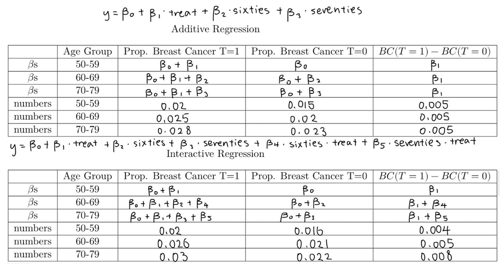

9. In (d), the estimated treatment effects within the 50-59, 60-69, and 70-79 group are 0.0037, 0.0046, and 0.0082 respectively. The results of the interactive model are similar to the results of (d), while the results of the addictive model are different. The difference between (f) and (g) is that (g) has two more terms, 60-69 * treatment and 70-79 * treatment, as regressors.

Dogs

```r
dog = read.csv("dogs.csv")
```

```r
dog$female = ifelse(dog$Gender == "Female", 1, 0)
dog$fixed = ifelse(dog$Fixed == "Yes", 1, 0)
lm5 = lm(Weight ~ female + fixed, data = dog)
stargazer(lm5, type = "text", title = "The Results of Regressing Weight on Gender and Fixed")
```

```
##
## The Results of Regressing Weight on Gender and Fixed
## ===============================================
##                         Dependent variable:
##                     ---------------------------
##                               Weight
## -----------------------------------------------
## female                        -2.619
##                               (2.725)
##
## fixed                          1.519
##                               (5.714)
##
## Constant                     45.643***
##                               (5.637)
##
## -----------------------------------------------
## Observations                    450
## R2                             0.002
## Adjusted R2                   -0.002
## Residual Std. Error      28.717 (df = 447)
## F Statistic             0.482 (df = 2; 447)
## ===============================================
## Note:               *p<0.1; **p<0.05; ***p<0.01
```

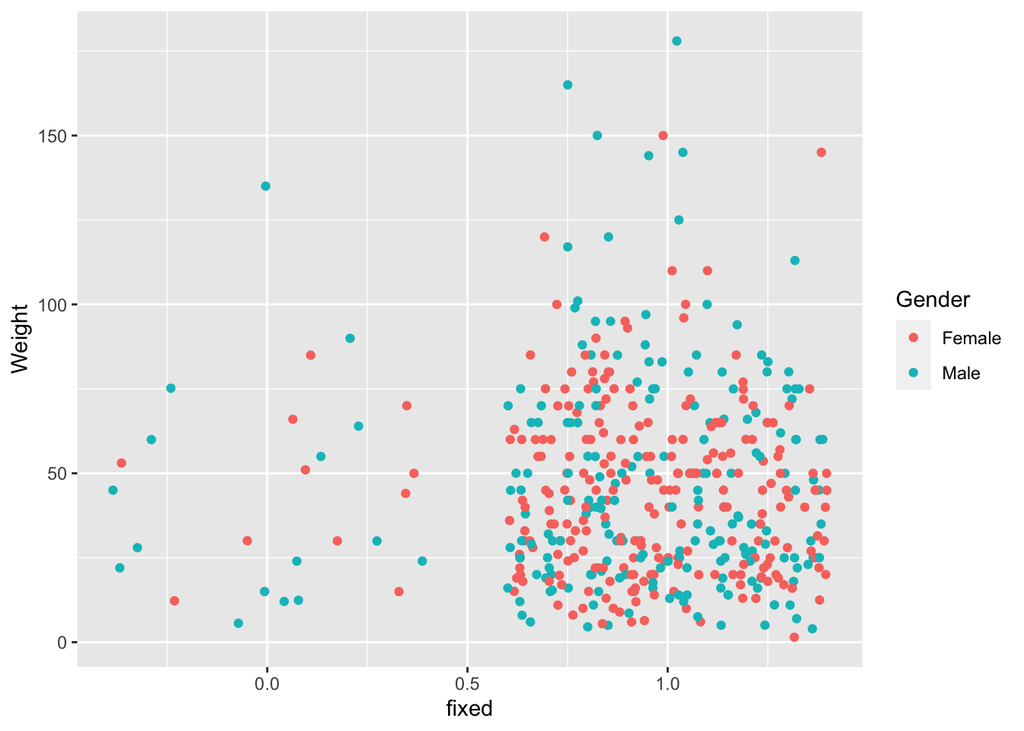

```r
ggplot(dog, aes(fixed, Weight, color = Gender)) +
  geom_jitter()
```

```r
lm6 = lm(Weight ~ female + fixed + female * fixed, data = dog)
stargazer(lm6, type = "text", title = "The Results of Regressing Weight on Gender, Fixed, and Gender*Fixed")
```

```
##
## The Results of Regressing Weight on Gender, Fixed, and Gender*Fixed
## ===============================================
##                         Dependent variable:
##                     ---------------------------
##                               Weight
## -----------------------------------------------
## female                         2.441
##                              (11.258)
##
## fixed                          3.755
##                               (7.484)
##
## female:fixed                  -5.376
##                              (11.603)
##
## Constant                     43.581***
##                               (7.186)
##
## -----------------------------------------------
## Observations                    450
## R2                             0.003
## Adjusted R2                   -0.004
## Residual Std. Error      28.742 (df = 446)
## F Statistic             0.392 (df = 3; 446)
## ===============================================
## Note:               *p<0.1; **p<0.05; ***p<0.01
```

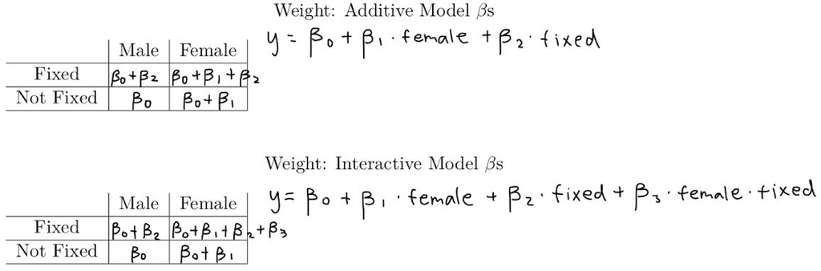

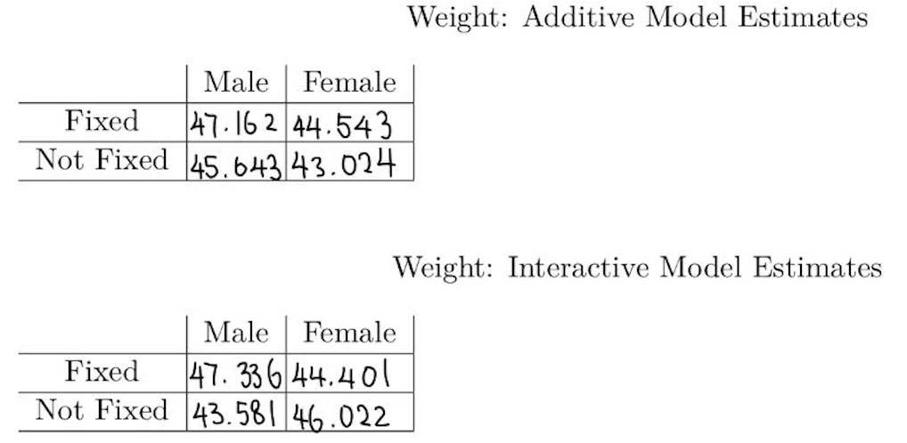

```r
mean(dog$Weight[dog$fixed==1 & dog$female==1], na.rm = T)
```

```
## [1] 44.40197
```

```r
mean(dog$Weight[dog$fixed==0 & dog$female==1], na.rm = T)
```

```
## [1] 46.02273
```

```r
mean(dog$Weight[dog$fixed==1 & dog$female==0], na.rm = T)
```

```
## [1] 47.33651
```

```r
mean(dog$Weight[dog$fixed==0 & dog$female==0], na.rm = T)
```

```
## [1] 43.58125
```

The sub-sample mean weights among fixed females, unfixed females, fixed males, and unfixed males are 44.4, 46.02, 47.34, and 43.58. The sub-sample mean weight of fixed females and fixed males are similar to the estimated weight of those calculated by the addictive model. The results of (g) are similar to the estimated weights calculated by the interactive model of (e).

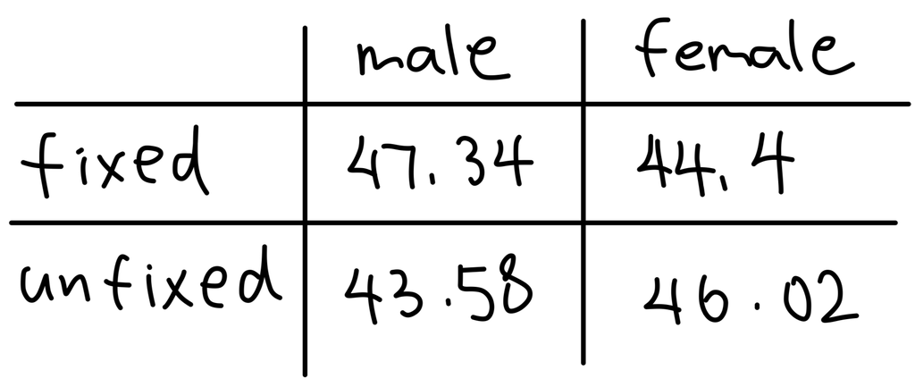